# Supplementary materials supporting the analysis of stone artefacts from Jerimalai rockshelter, East Timor.

Ben Marwick

This document contains the code to accompany the analysis of stone artefacts from Jerimalai rockshelter reported in Marwick et al. This document is organised with the same structure as the manuscript and will produce all of the quantitative results, data visualisations and tables found in the manuscript.

Please see the readme.md file for details on how to execute the code in this document.

### Chronology of the excavated deposit

In this section we analyse the dates to determine the ages of each phase

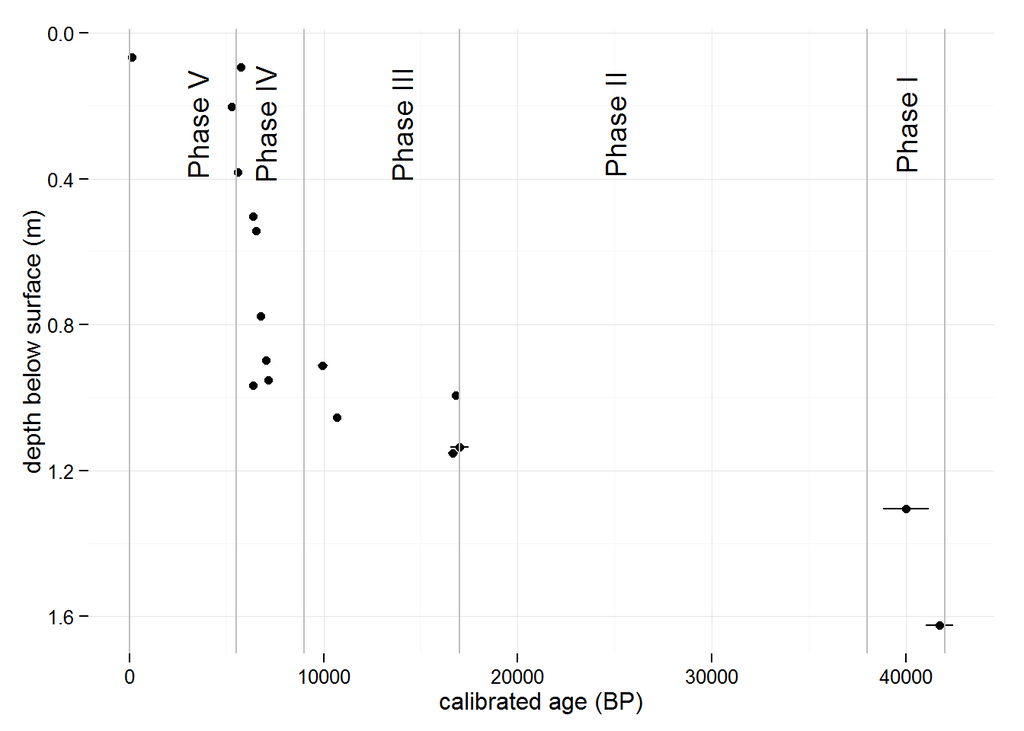

```r
# plot dates and label with phases

dates$cal_age_min <- as.numeric(gsub("\\D", "", dates$cal_age_min))
dates$cal_age_max <- as.numeric(gsub("\\D", "", dates$cal_age_max))
dates$mid <- with(dates, cal_age_min + ((cal_age_max - cal_age_min) /2) )
ggplot(dates, aes(mid, depth_bs)) +
  geom_point() +
  scale_y_reverse() +
  geom_errorbarh(aes(xmin=cal_age_min,xmax=cal_age_max,  height = 0)) +
  theme_minimal() +
  #geom_smooth(span = 0.19, se = FALSE) +
  ylab("depth below surface (m)") +
  xlab("calibrated age (BP)") +
  geom_vline(xintercept = 42000, colour = 'grey') +
  annotate("text", x = 40000, y = 0.25, label = "Phase I", angle = 90) +
  geom_vline(xintercept = 38000, colour = 'grey') +
  geom_vline(xintercept = 17000, colour = 'grey') +
  annotate("text", x = 25000, y = 0.25, label = "Phase II", angle = 90) +
  geom_vline(xintercept = 9000, colour = 'grey') +
  annotate("text", x = 14000, y = 0.25, label = "Phase III", angle = 90) +
  geom_vline(xintercept = 5500, colour = 'grey') +
  annotate("text", x = 7000, y = 0.25, label = "Phase IV", angle = 90) +
  geom_vline(xintercept = 5500,colour = 'grey') +
  geom_vline(xintercept = 0, colour = 'grey') +
  annotate("text", x = 3500, y = 0.25, label = "Phase V", angle = 90)
```

```r
  theme( # remove the vertical grid lines
    panel.grid.major.x = element_blank() ,
    # explicitly set the horizontal lines (or they will disappear too)
    panel.grid.major.y = element_blank()
  )
```

```
## List of 2
##  $ panel.grid.major.x: list()
##   ..- attr(*, "class")= chr [1:2] "element_blank" "element"
##  $ panel.grid.major.y: list()
##   ..- attr(*, "class")= chr [1:2] "element_blank" "element"
##  - attr(*, "class")= chr [1:2] "theme" "gg"
##  - attr(*, "complete")= logi FALSE
```

```r
# From Science paper - four chonological divisions
# The chronological divisions are:
# Phase I (spits 69-50) dated ~42 to 38 ka;
# Phase II (spits 49-40) # dated between ~ 17 to 9 ka,
# Phase III (spits 39-21) dated between 6.5 and 5.5 ka,
# Phase IV (spits 20-3) dated ~5.5 - modern.

# I have chosen not to omit 17-38 ky BP here

ggsave("figures/Jeremalai-dates.png")
```

## Results

### Raw materials

Here we investigate the distribution of different raw materials over time. First we assign all of the flakes to one of the five phases.

```r
# omit rows with blanks or NAs
flakes <- flakes[!(flakes$Weight == "" | is.na(flakes$Weight)), ]

# put depths on lithic data
flakes$depth <- depths$Depth.bs..m[match(flakes$Spit,depths$Spit.no)]

# omit rows with blanks or NAs... again
flakes <- flakes[!(flakes$depth == "" | is.na(flakes$depth)), ]

# From Science paper - four chonological divisions
# The chronological divisions are:
# Phase I (spits 69-50) dated ~42 to 38 ka;
# Phase II (spits 49-40) # dated between ~ 17 to 9 ka,
# Phase III (spits 39-21) dated between 6.5 and 5.5 ka,
# Phase IV (spits 20-3) dated ~5.5 - modern.

flakes$phase <- ifelse(flakes$Spit > 0 & flakes$Spit <= 20, 4,
                       ifelse(flakes$Spit >= 21 & flakes$Spit <= 39, 3,
                              ifelse(flakes$Spit >= 40 & flakes$Spit <= 49, 2,
                                     ifelse(flakes$Spit >= 50 & flakes$Spit <= 69, 1, NA))))
# check if any NA
check <- unique(flakes$phase)

# My version after Sue's comment
# The chronological divisions are:
# Phase I (spits 69-56) dated ~42 to 38 ka;
# Phase II (spits 55-49) # dated between ~ 38 to 17 ka,
# Phase III (spits 48-40) # dated between ~ 17 to 9 ka,
# Phase IV (spits 39-21) dated between 6.5 and 5.5 ka,
# Phase V (spits 20-3) dated ~5.5 - modern.


# here's a function to assign phases based on spit numbers
  makephases <- function(x) {ifelse(x > 0 & x <= 20, 5,
                       ifelse(x >= 21 & x <= 39, 4,
                              ifelse(x >= 40 & x <= 48, 3,
                                     ifelse(x >= 49 & x <= 55, 2,
                                            ifelse(x >= 56 & x <= 69, 1, NA)))))}

flakes <- flakes[!(is.na(flakes$Spit)),]
flakes$phase  <- makephases(flakes$Spit)
# check if any NA, don't want any, should return all TRUE
# is.na(unique(flakes$phase)) %in% FALSE
# get phase durations
phases <- data.frame(phase = 1:5,
                     start = c(42, 38, 17, 6.5, 5.5),
                     end =   c(38, 17, 9,  5.5, 0 ))
phases$duration <- with(phases, start - end)
```

Then we can summarise and plot the raw materials in each phase.

```r
# raw material
raw <- dcast(flakes, Material ~ phase) # change group to depth for hi res
```

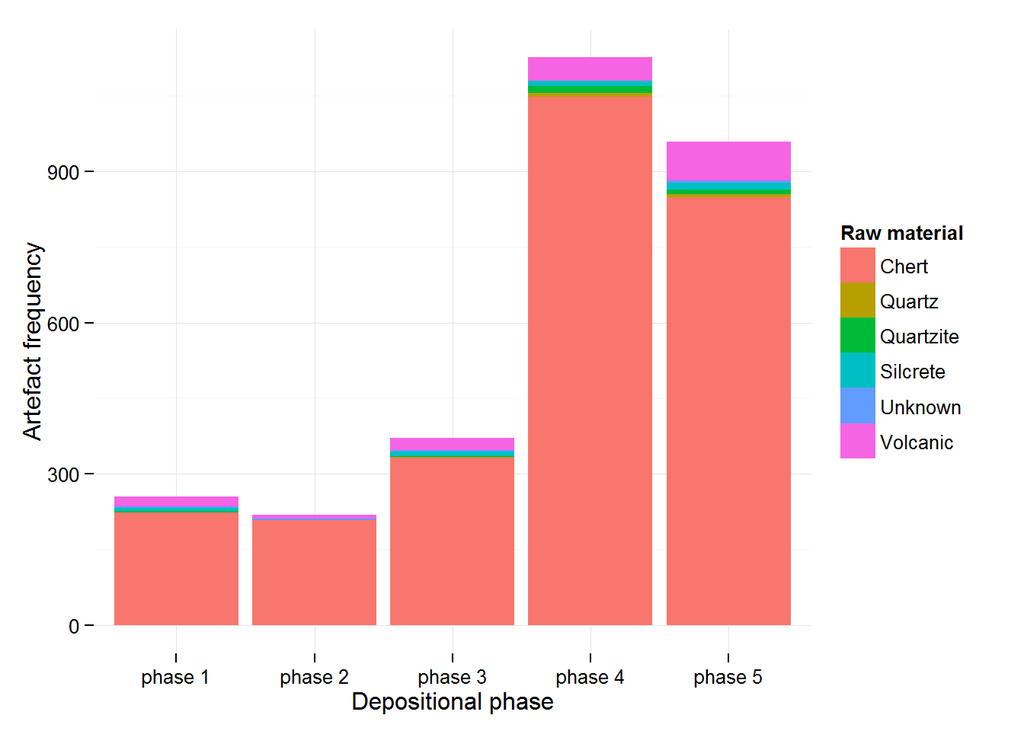

```r
# remove row with no raw material
raw <- raw[-10,]
rownames(raw) <- raw[,1]
# get rid of rows with no value
raw <- raw[rownames(raw) != "",]
# remove col of NA
raw <- raw[,colnames(raw) != "NA"]
raw <- raw[,-1]
# stat test on all

# plot dominant raw materials
dom <- raw[rowSums(raw) > 10,]
colnames(dom) <- c("phase 1", "phase 2", "phase 3", "phase 4", "phase 5" )
dom_m <- dom
dom_m$raw_type <- rownames(dom_m)
dom_m <- melt(dom_m)
ggplot(dom_m, aes(variable, value, fill = raw_type)) +
  geom_bar(stat="identity") +
  theme_minimal() +
  xlab("Depositional phase") +
  ylab("Artefact frequency") +
  scale_fill_discrete(name="Raw material")
```

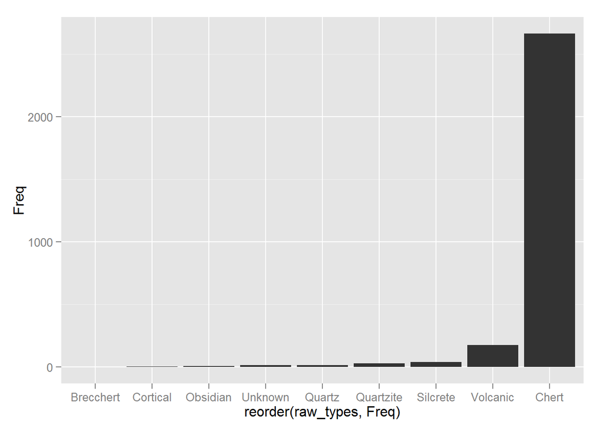

```r
# save plot
ggsave("figures/Jeremalai-raw-materials-group-counts.png")
# table: subset raw materials with more than 10 pieces per phase,
# include obsidian ouot of interest
dom_obs <- raw[rowSums(raw) > 10 | row.names(raw) == 'Obsidian',]
#print(xtable(dom_obs), type = 'html', html.table.attributes = (border=0), file = "raw_tab.html")

raw_freqs <- data.frame(raw_types = rownames(raw), Freq = rowSums(raw))
ggplot(raw_freqs, aes(reorder(raw_types, Freq), Freq)) +
  geom_bar(stat="identity")
```

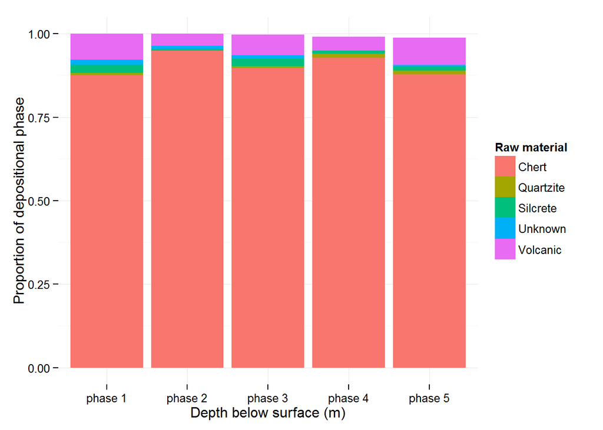

```r
# raw materials by site
# compute proportions per layer (col props)
all_tab <- data.frame()
for(i in seq(ncol(raw))){
  for(j in seq(nrow(raw))){
    all_tab[j,i] <- raw[j,i]/colSums(raw)[i]
  }
}
# check
# colSums(all_tab) # should == 1
# colnames(all_tab) <- colnames(raw)
# rowSums(all_tab) # should be various
all_tab$raw_type <- rownames(raw)
# get rid of raw materials that are not very abundant
all_tab <- all_tab[which(rowSums(all_tab[,1:ncol(all_tab)-1]) > 0.02) , ]

# get rid of NA column
all_tab <- all_tab[,names(all_tab) != 'NA']
# set column names
colnames(all_tab) <- c("phase 1", "phase 2", "phase 3", "phase 4", "phase 5", "raw_type" )

# plot
all_tab_m <- melt(all_tab, id.var = 'raw_type')
ggplot(all_tab_m, aes(variable, value, fill = raw_type)) +
  geom_bar(stat="identity") +
  theme_minimal() +
  xlab("Depth below surface (m)") +
  ylab("Proportion of depositional phase") +
  scale_fill_discrete(name="Raw material")
```

```r
# save plot
ggsave("figures/Jeremalai-raw-materials-group.png")
```

Here is the table “Counts of major raw materials of complete flakes per depositional phase”:

```r
raw[!(row.names(raw) %in% c('Brecchert', 'Cortical', 'Unknown')),]
```

```
##             1   2   3    4   5
## Chert     224 208 333 1048 849
## Obsidian    0   0   0    1   5
## Quartz      0   0   1    8   6
## Quartzite   2   0   2   14  10
## Silcrete    6   1   8   11  13
## Volcanic   20   8  23   46  78
```

Here is the code to compute a test of credible differences of raw material coutns and phases:

```r
# bayesian contingency table test...
# reshape and give meaningful names...

data <- melt(as.matrix(dom),  varnames=c("raw_material", "phase"), value.name="Freq")
data <- data[data$Freq != 0 | !is.numeric(data$Freq),] # zeros break the model
# This script is in the same folder as the current script
# and generates plots and a lot of data objects. The only
# input is a long data.frame called 'data' that has a last
# column called 'Freq'

# uncomment this next line to run test (it will take a few minutes)
# source("code/BensPoissonExponentialJagsSTZ.R")

# all interactions include zero in the HDI, so no credible differences
# in raw materials between phases.

# here is the frequentist equivalent for skeptics:

results <- chisq.test(raw, simulate.p.value=T, B=9999)
# a few diagnostics
# results$expected
# prop.table(raw)
# colSums(prop.table(raw))
# rowSums(prop.table(raw))
# stat test on just dominant materials
tab <- prop.table(as.matrix(raw[rowSums(raw) > 20,]), 2)
# a slight decrease in chert in Holocene
result <- chisq.test(dom, simulate.p.value=FALSE, B=999)
# so it's significant in the frequentist system, but what's the strength?
# Cramer's V: is a measure of association for nominal variables. Effectively it is the Pearson chi-square statistic rescaled to have values between 0 and 1,
cramers_V <- assocstats(as.matrix(dom)) # very small V
```

Compute summary for chert artefacts cortex types:

```r
cortex_type <- as.data.frame(table(flakes$Cortype))[-1,]

cortex_type$prop <- round(prop.table(cortex_type$Freq),2)
```

The chert artefacts have a combination of rounded cortex (35%) and angular cortex (65%)

### Discard rates

```
## geom_smooth: method="auto" and size of largest group is <1000, so using loess. Use 'method = x' to change the smoothing method.
```

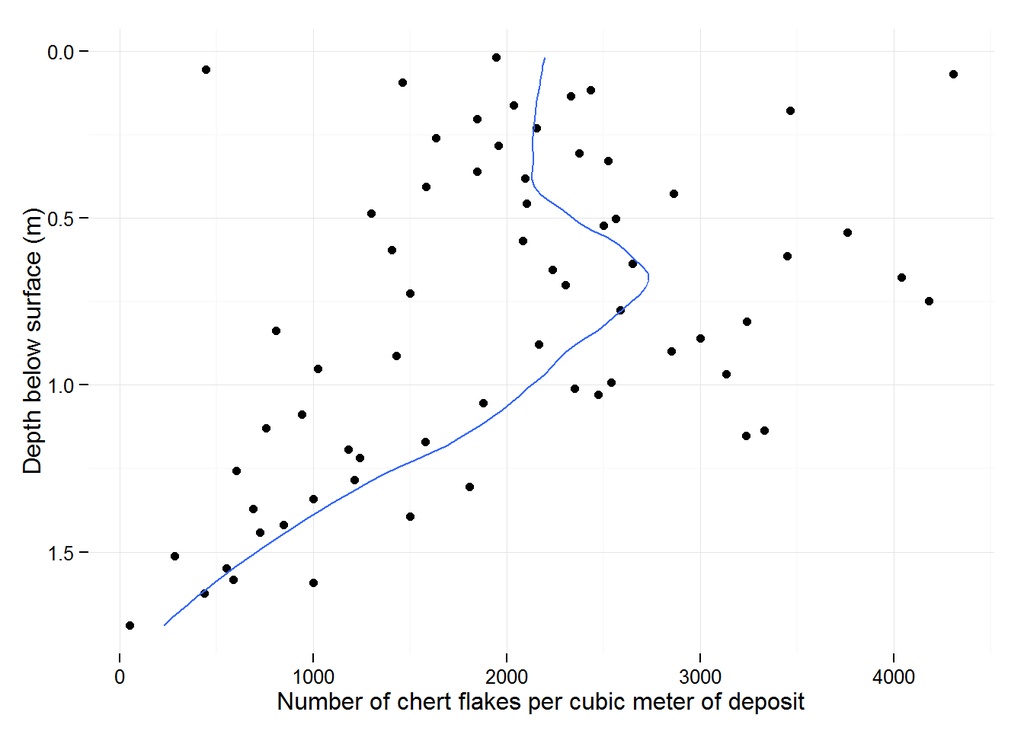

```r
# discard rates
discard <- aggregate(Weight ~ depth + Spit, flakes, length)

# sediment volumes: put volumes on
discard$sedvol <- vols$Soil[match(discard$Spit, vols$X)]
# put spit thickesses on
discard$thick <- c(0.018, diff(discard$depth)) # add first value from depth_and_dates.xsl
# compute artefacts per kg of sediment
discard$kgsed <- with(discard, Weight / sedvol) # weight is count of artefacts that have a weight
# compute artefact per cubic meter (spit thickess)
discard$cubmet <- with(discard, Weight / thick)
# seems we have an unusually extreme value in spit 34
# omit - perhaps a data collection typo
discard <- discard[discard$Spit != 34, ]
# Plot
ggplot(discard, (aes(depth, cubmet))) +
  geom_point() +
  theme_minimal() +
  stat_smooth(span = 0.5, se = FALSE) +
  xlab("Depth below surface (m)") +
  ylab("Number of chert flakes per cubic meter of deposit") +
  coord_flip() +
  scale_x_reverse()
```

```r
# save plot
ggsave("figures/Jeremalai-flake-discard.png")
```

```
## geom_smooth: method="auto" and size of largest group is <1000, so using loess. Use 'method = x' to change the smoothing method.
```

Here is the code the generates the figure “Discard rates of chert artefacts per depositional phase at Jerimalai square B”

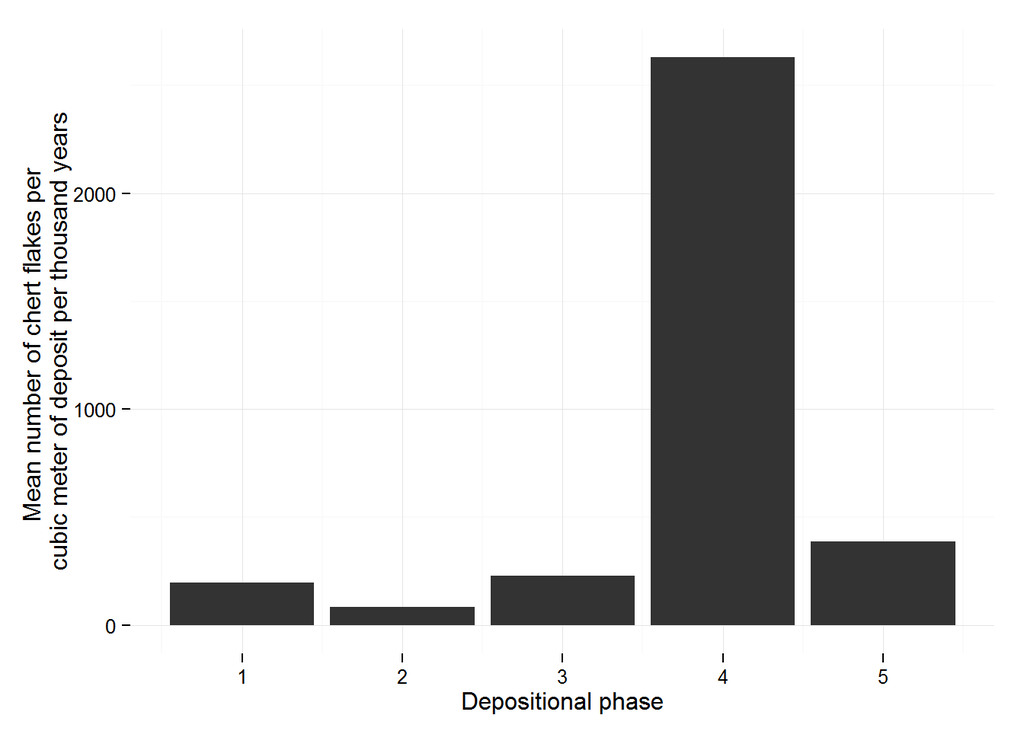

```r
# plot artefacts/cubic meter/1000 years by phase, get phase number for each spit
# this is the most sensible option
discard$phase <- makephases(discard$Spit)
discard_agg <- aggregate(cubmet ~ phase, discard, mean)
discard_agg$cubmetperkyr <- discard_agg$cubmet / phases$duration
ggplot(discard_agg, (aes(phase, cubmetperkyr))) +
  geom_bar(stat="identity") +
  theme_minimal() +
  xlab("Depositional phase") +
  ylab("Mean number of chert flakes per \ncubic meter of deposit per thousand years")
```

```r
# save plot
ggsave("figures/Jeremalai-flake-discard-phase-m3.png")
```

### Artefact taphonomy

Here is the code for the plot “Frequencies of complete flakes, transversely broken flakes and longitudinally broken flakes made from chert in each depositional unit at Jerimalai square B”

```r
allchert <- all[all$Material == 'Chert', ]
allchert$phase <- makephases(allchert$Spit)
# make Artclass that is long and transv breaks
allchert$Artclas <- ifelse(allchert$Breaks == "",
       as.character(allchert$Artclas),
       paste(allchert$Artclas, allchert$Breaks, sep = "-"))

taph <- data.frame(table(allchert$Artclas))

# use regex to get broken flakes -b-
broken <- allchert[grep("-b", allchert$Artclas), ]


# get counts of broken to complete per phase
# flake to -b-

breaks <- dcast(allchert, Artclas ~ phase)[-1,]
breaks <- breaks[breaks$Artclas =="Flake" | grepl("-b-", breaks$Artclas), ]

allchert$Artclas <- tolower(allchert$Artclas)
allchert$breakt <- "" # create variable to fill

allchert$breakt[grep("trans", allchert$Artclas)] <- "trans"
allchert$breakt[grep("long", allchert$Artclas)] <- "long"

# per depositional phase

breakt <- dcast(allchert, breakt ~ phase)[-1,]
```

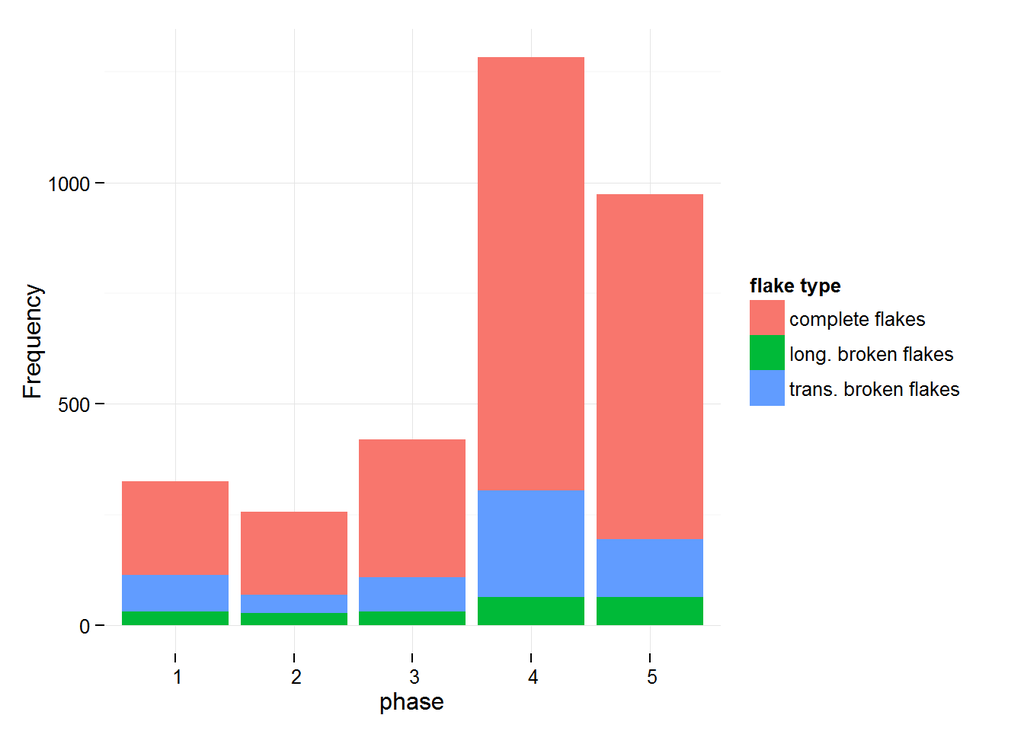

```r
# add complete flake counts
breakt <- rbind( breakt , setNames( breaks[1, ] , names( breakt ) ) )
# shift rownames out and delete them
rownames(breakt) <- breakt[,1]
breakt <- breakt[,-1]
# stat test
freq_test <- assocstats(as.matrix(breakt))

# do bayesian contingency table test
colnames(breakt) <- c("phase 1", "phase 2", "phase 3", "phase 4", "phase 5" )
data <- melt(as.matrix(breakt),  varnames=c("breakt", "phase"), value.name="Freq")
data <- data[data$Freq != 0,] # zeros break the model


# plot
data$phase <- gsub("[[:alpha:]]*", "", data$phase)
# recode break type for pretty legend
data$breakt <- with(data, ifelse(breakt == 'long', 'long. broken flakes',
        ifelse(breakt == "trans", "trans. broken flakes",
               ifelse(breakt == "Flake", "complete flakes", NA))))
ggplot(data, aes(phase, Freq, fill = breakt)) +
  ylab("Frequency") +
  geom_bar(stat = "identity") +
  theme_minimal() +
  scale_fill_discrete(name="flake type")
```

```r
ggsave("figures/Jeremalai-flake-broken-phase.png")
```

```r
# This script is in the same folder as the current script
# and generates plots and a lot of data objects. The only
# input is a long data.frame called 'data' that has a last
# column called 'Freq'
# source("code/BensPoissonExponentialJagsSTZ.R")
```

Here is the code to summarise heat treatment.

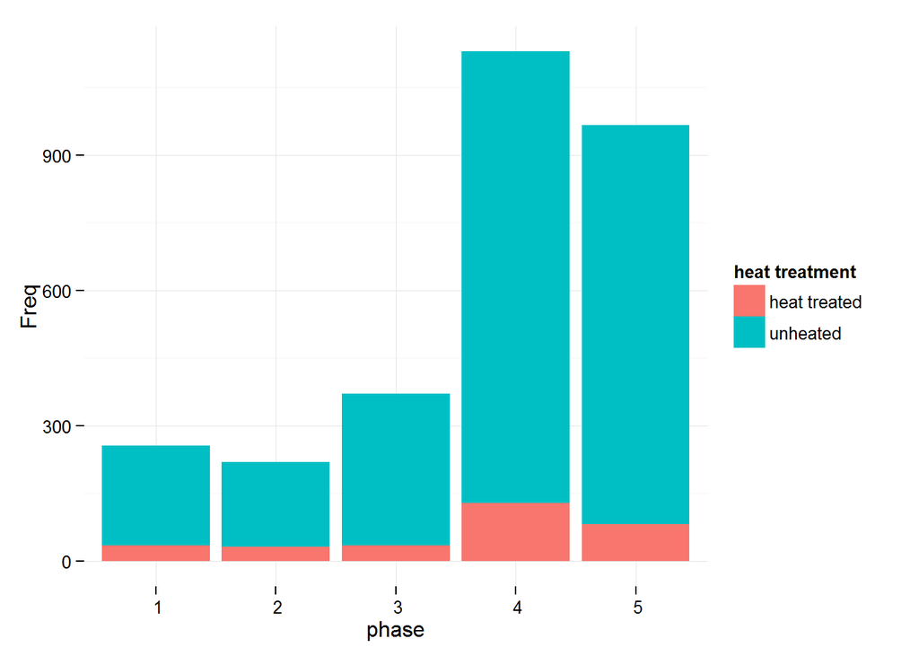

```r
check <- sum(flakes$Heat, na.rm = TRUE) / nrow(flakes)
heat <- aggregate(Heat ~ phase, flakes, length)
total <- aggregate(Spit ~ phase, flakes, length)
heat$notheat <- total$Spit - heat$Heat
# show proportions that are heat-treated
max_heat <- max(heat$Heat / total$Spit)
min_heat <- min(heat$Heat / total$Spit)
heat <- t(heat)

# frequentist stat test
freq_test <- assocstats(as.matrix(heat))

# do bayesian contingency table test
colnames(heat) <- c("phase 1", "phase 2", "phase 3", "phase 4", "phase 5" )
heat <- heat[-1,]
data <- melt(as.matrix(heat),  varnames=c("heat", "phase"), value.name="Freq")
data <- data[data$Freq != 0,] # zeros break the model
# This script is in the same folder as the current script
# and generates plots and a lot of data objects. The only
# input is a long data.frame called 'data' that has a last
# column called 'Freq'
# source("code/BensPoissonExponentialJagsSTZ.R")

# plot
data$phase <- gsub("[[:alpha:]]*", "", data$phase)
ggplot(data, aes(phase, Freq, fill = heat)) +
  geom_bar(stat = "identity") +
  theme_minimal() +
  scale_fill_discrete(name="heat treatment",
                      labels=c("heat treated",
                               "unheated"))
```

```r
ggsave("figures/Jeremalai-flake-heat-phase.png")
```

Between 8% and 15% of chert artefacts in each depositional phase show signs of having been heated, such as crenation, potlid scars or surface crazing.

### Metric and technological characteristics of cores and unretouched flakes

Here is the code for the table “Summary of attributes of chert complete flakes from Jerimalai square B. Each cell contains mean ± standard deviation unless otherwise indicated.” The table produced here has been rearranged by hand for the paper.

```r
# the table has been rearranged by hand for the paper
metrics <- flakes %.%
  group_by(phase) %.%
  summarise(mean(Length, na.rm = TRUE),
            mean(Width, na.rm = TRUE),
            mean(Thick, na.rm = TRUE),
            mean(Weight, na.rm = TRUE),
            mean(Length, na.rm = TRUE),
            mean(Platwid, na.rm = TRUE),
            mean(Platthic, na.rm = TRUE),
            mean(NoDS, na.rm = TRUE),
            mean(Cortex, na.rm = TRUE),
            sd(Length, na.rm = TRUE),
            sd(Width, na.rm = TRUE),
            sd(Thick, na.rm = TRUE),
            sd(Weight, na.rm = TRUE),
            sd(Length, na.rm = TRUE),
            sd(Platwid, na.rm = TRUE),
            sd(Platthic, na.rm = TRUE),
            sd(NoDS, na.rm = TRUE),
            sd(Cortex, na.rm = TRUE),
            n = length(Weight))

# get overhang removal data also
ohr <- filter(flakes, Overhang == "Yes") %>%
       group_by(phase) %>%
       summarise(OHR_n = length(Overhang))
# get percentages of OHR per phase
ohr$OHR_perc <- ohr$OHR_n/metrics$n * 100

# combine
metrics <- cbind(metrics, ohr[,c("OHR_n", "OHR_perc")])
metrics <- t(round(metrics,2))
# show
metrics
```

```
##                                [,1]   [,2]   [,3]    [,4]   [,5]
## phase                          1.00   2.00   3.00    4.00   5.00
## mean(Length, na.rm = TRUE)    10.93  10.65   9.38   10.77  12.18
## mean(Width, na.rm = TRUE)      9.73   9.79   8.80   10.13  11.10
## mean(Thick, na.rm = TRUE)      2.94   2.84   2.41    2.84   3.32
## mean(Weight, na.rm = TRUE)     0.77   0.60   0.40    0.70   1.16
## mean(Platwid, na.rm = TRUE)    7.56   7.23   6.81    7.70   8.35
## mean(Platthic, na.rm = TRUE)   2.98   2.77   2.36    2.77   3.24
## mean(NoDS, na.rm = TRUE)       3.89   4.01   3.91    3.96   3.96
## mean(Cortex, na.rm = TRUE)     3.77   3.13   2.53    2.98   4.11
## sd(Length, na.rm = TRUE)       7.10   6.00   5.55    6.20   7.90
## sd(Width, na.rm = TRUE)        5.67   5.17   4.55    6.54   6.83
## sd(Thick, na.rm = TRUE)        2.37   2.27   1.88    2.26   2.67
## sd(Weight, na.rm = TRUE)       1.98   1.04   0.76    1.75   3.20
## sd(Platwid, na.rm = TRUE)      4.57   4.51   3.98    4.98   5.36
## sd(Platthic, na.rm = TRUE)     2.23   2.21   1.80    2.09   2.55
## sd(NoDS, na.rm = TRUE)         2.04   2.16   2.05    2.45   2.03
## sd(Cortex, na.rm = TRUE)      13.59  12.30  11.63   11.82  14.18
## n                            256.00 219.00 371.00 1130.00 966.00
## OHR_n                        136.00 123.00 198.00  651.00 575.00
## OHR_perc                      53.12  56.16  53.37   57.61  59.52
```

Here is the code for the test of credible differences of flake mass by phase.

```r
# ANOVA with Tukey's HSD
fit <- aov(Weight ~ as.factor(phase), flakes)
# summary(fit)
tuk <- TukeyHSD(fit)
# plot(tuk, las = 2, cex = 0.1)

# do bayesian ANOVA
data <- data.frame(phase = flakes$phase, mass = flakes$Weight)
data <- data[data$mass != 0,] # zeros break the model
# This script is in the same folder as the current script
# and generates plots and a lot of data objects. The only
# input is a long data.frame called 'data' that has col1
# as numbers indicating groups and col2 as the measurement
# source("code/BensANOVAonewayJagsSTZ.R")
```

Here is the code for the table “Summary of metric attributes of chert complete cores from Jerimalai square B”

```r
cores_mass <- allchert[allchert$Artclas == "core", ]
core_metrics <- cores_mass %.%
  group_by(phase) %.%
  summarise(mean(Weight),
            mean(Length),
            mean(Width),
            mean(Thick),
            sd(Weight),
            sd(Length),
            sd(Width),
            sd(Thick),
            n = length(Weight))
t(round(core_metrics,2))
```

```
##               [,1]  [,2]  [,3]  [,4]  [,5]
## phase         1.00  2.00  3.00  4.00  5.00
## mean(Weight) 17.97 23.75  3.90  3.19  5.59
## mean(Length) 25.56 26.10 18.75 18.97 21.58
## mean(Width)  19.90 19.62 14.23 14.65 15.77
## mean(Thick)  12.59 13.74  8.41  9.16  9.73
## sd(Weight)   36.34 57.91  4.29  2.60  6.50
## sd(Length)   14.99 12.92  6.97  6.73  9.12
## sd(Width)    12.92 12.90  6.86  4.67  8.01
## sd(Thick)     9.16  9.72  3.76  3.13  4.17
## n            16.00 20.00 12.00 37.00 43.00
```

Here is the code for the figure “Distribution of core and complete flake mass by depositional phases”

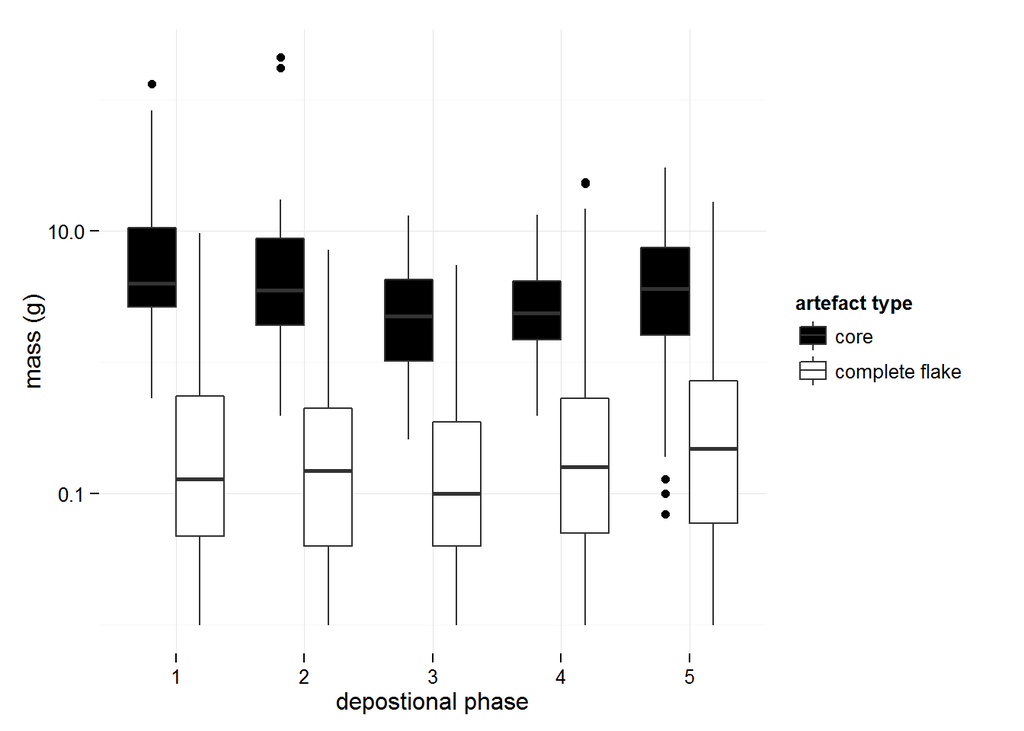

```r
# plot flake and core mass by phase in one box plot
flakes_cores_weight <- allchert[(allchert$Artclas == "flake" | allchert$Artclas == "core"), c('Artclas', 'Weight', 'phase') ]

ggplot(flakes_cores_weight, aes( fill = Artclas, as.factor(phase), Weight)) +
  geom_boxplot() +
  scale_y_log10() +
  theme_minimal() +
  xlab('depostional phase') +
  ylab("mass (g)") +
  scale_fill_manual(name="artefact type",
                      labels=c("core", "complete flake"),
                      values = c("black", "white"))
```

```r
# save plot
ggsave("figures/Jeremalai-flake-core-mass-phase.png")
```

Here is the code for tests of credible difference in core mass by phase

```r
# ANOVA with Tukey's HSD
fit <- aov(Weight ~ as.factor(phase), cores_mass)
summry <- summary(fit)
tuk <- TukeyHSD(fit)
# plot(tuk, las = 2, cex = 0.1)

# do bayesian ANOVA
data <- data.frame(phase = cores_mass$phase, mass = cores_mass$Weight)
data <- data[data$mass != 0,] # zeros break the model)
# This script is in the same folder as the current script
# and generates plots and a lot of data objects. The only
# input is a long data.frame called 'data' that has col1
# as numbers indicating groups and col2 as the measurement
# source("code/BensANOVAonewayJagsSTZ.R")
```

This is the code for the figures that make up “Frequency of flake platform category for chert complete flakes at Jerimalai square B. subplot: distribution of platform area by category.” The final version of the figure is generated as a png file when the code is executed but does not show in this document.

```r
# flake platform
plat <- dcast(flakes, Plat ~ depth)
```

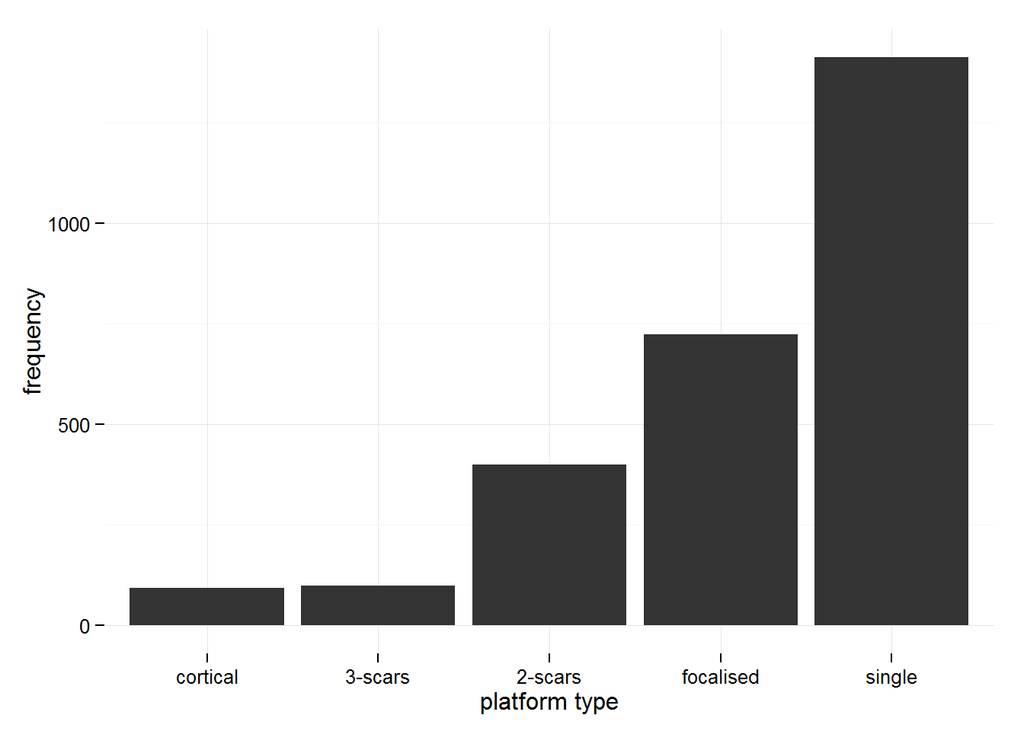

```r
rownames(plat) <- plat[,1]
# get rid of rows with no plat
plat <- plat[rownames(plat) != "",]
plat <- plat[,-1]
# stat test on all
# frequentist stat test
freq_test <- assocstats(as.matrix(plat))
chisq <- chisq.test(plat, simulate.p.value=T, B=999)
# stat test on just dominant plats
chisq <-chisq.test(plat[rowSums(plat) > 70,], simulate.p.value=T, B=999)
freq_test <-assocstats(as.matrix(plat[rowSums(plat) > 70,]))
plat_freqs <- data.frame(plat_types = rownames(plat), Freq = rowSums(plat))
plat_freqs <- plat_freqs[plat_freqs$Freq > 90,]
plat_freqs$plat_types <- c('2-scars', '3-scars', 'cortical', 'focalised', 'single')
# plot freq of platform types
main <- ggplot(plat_freqs, aes(reorder(plat_types, Freq), Freq)) +
  geom_bar(stat="identity") +
  # theme_minimal() +
  xlab("platform type") +
  ylab("frequency") +
  # remove grid lines for subplot
  theme_update(panel.background = element_blank(),
               panel.grid.major = element_blank(),
               panel.grid.minor = element_blank())
main + theme_minimal()
```

```r
# raw materials by spit
# compute proportions per layer (col props)
all_tab <- data.frame()
for(i in seq(ncol(plat))){
  for(j in seq(nrow(plat))){
    all_tab[j,i] <- plat[j,i]/colSums(plat)[i]
  }
}
# check
check <- colSums(all_tab) # should == 1
colnames(all_tab) <- colnames(plat)
check <- rowSums(all_tab) # should be various
all_tab$plat_type <- rownames(plat)
# get rid of raw materials that are not very abundant
all_tab <- all_tab[which(rowSums(all_tab[,1:ncol(all_tab)-1]) > 1.5) , ]

# get rid of NA column
all_tab <- all_tab[,names(all_tab) != 'NA']
# stat test
chisq <- chisq.test(all_tab[,-ncol(all_tab)])
```

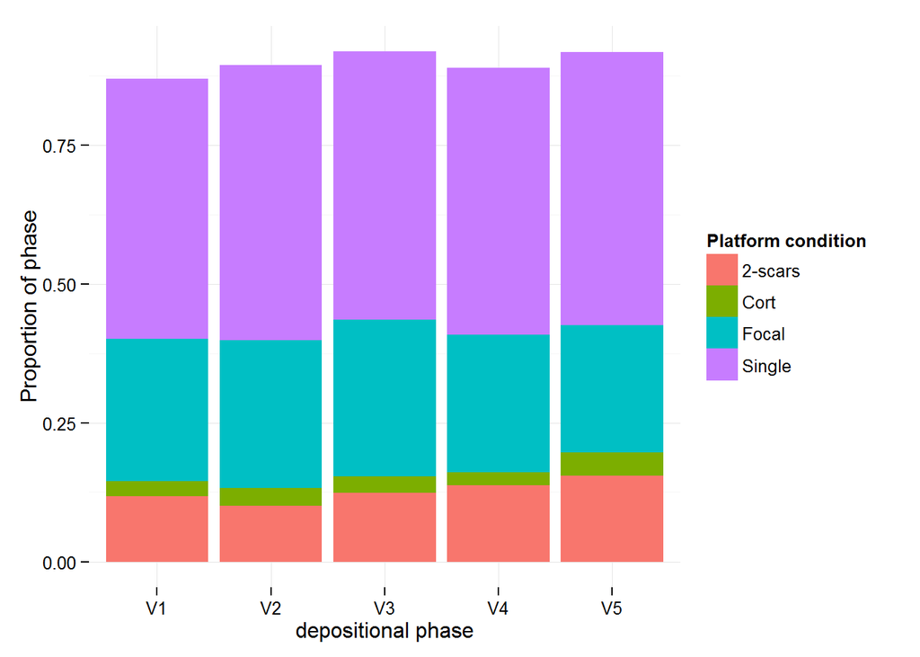

```r
freq_test <- assocstats(as.matrix(all_tab[,-ncol(all_tab)]))
# plot
all_tab_m <- melt(all_tab, id.var = 'plat_type')


# by phase
plat <- dcast(flakes, Plat ~ phase)
rownames(plat) <- plat[,1]
# get rid of rows with no plat
plat <- plat[rownames(plat) != "",]
plat <- plat[,-1]
# stat test on all
# frequentist stat test
freq_test <- assocstats(as.matrix(plat))
ch_sq <- chisq.test(plat, simulate.p.value=T, B=999)
# stat test on just dominant plats
chisq <- chisq.test(plat[rowSums(plat) > 20,], simulate.p.value=T, B=999)
freq_test <- assocstats(as.matrix(plat[rowSums(plat) > 20,]))

# raw materials by site
# compute proportions per phase (col props)
all_tab <- data.frame()
for(i in seq(ncol(plat))){
  for(j in seq(nrow(plat))){
    all_tab[j,i] <- plat[j,i]/colSums(plat)[i]
  }
}
# check
# colSums(all_tab) # should == 1
# colnames(all_tab) <- colnames(plat)
# rowSums(all_tab) # should be various
all_tab$plat_type <- rownames(plat)
# get rid of raw materials that are not very abundant
all_tab <- all_tab[which(rowSums(all_tab[,1:ncol(all_tab)-1]) > 0.15) , ]

# get rid of NA column
all_tab <- all_tab[,names(all_tab) != 'NA']
# stat test
chi_sq <- chisq.test(all_tab[,-ncol(all_tab)])
# plot
all_tab_m <- melt(all_tab, id.var = 'plat_type')
ggplot(all_tab_m, aes(variable, value, fill = plat_type)) +
  geom_bar(stat="identity") +
  theme_minimal() +
  xlab("depositional phase") +
  ylab("Proportion of phase") +
  scale_fill_discrete(name="Platform condition")
```

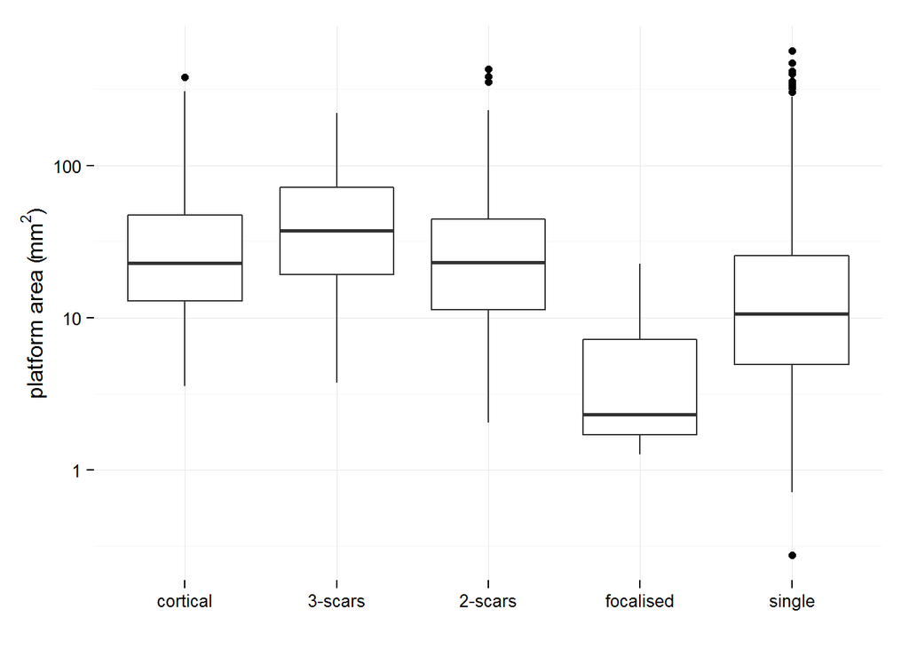

```r
ggsave("figures/Jeremalai-platform-phase.png")
# plot distibution of platform sizes for each type
flakes$Platarea <- with(flakes, (Platthic * Platwid))
plat_area_type <- flakes[flakes$Plat %in% c("Single", "Focal", "2-scars", "Cort", '3-scars'),]

# make names a bit more readable
plat_area_type$Plat <- ifelse(plat_area_type$Plat == 'Cort', 'cortical',
                      ifelse(plat_area_type$Plat == 'Focal',  'focalised',
                    ifelse(plat_area_type$Plat == 'Single',  'single', as.character(plat_area_type$Plat))))

# put types in same order as frequency plot
plat_area_type$Plat <- factor(plat_area_type$Plat,
                              levels = c('cortical', '3-scars','2-scars', 'focalised', 'single'), ordered = TRUE)

sub <- ggplot(plat_area_type, aes(Plat, Platarea)) +
  geom_boxplot() +
  scale_y_log10() +
  ylab(as.expression(bquote('platform area (' * mm^{2} * ")" ))) +
  xlab("") +
  theme_minimal()
ggsave("figures/Jeremalai-platform-area-by-phase.png")
sub
```

```r
# plot freq of plat type and platform area together in one plot

vp <- viewport(width = 0.4, height = 0.5,
               x = 0.5, y = 0.4,
               just = c("right", "bottom"))

# combine plots, print and save (wont show in console)
png("figures/Jeremalai-platform-area-by-plat-type.png", w = 650, h = 350)
   print(main)
   print(sub + theme_bw(base_size = 10), vp = vp)
dev.off()
```

```r
# test for diff in area between types
plat_type_area_test <- na.omit(flakes[flakes$Plat %in% c("Single", "Focal", "2-scars"),c('Plat', 'Platarea')])

# ANOVA with Tukey's HSD
fit <- aov(Platarea ~ as.factor(Plat), plat_type_area_test)
summary(fit)
```

```
##                   Df  Sum Sq Mean Sq F value Pr(>F)
## as.factor(Plat)    2   73034   36517    17.2  4e-08 ***
## Residuals       1812 3845534    2122
## ---
## Signif. codes:  0 '***' 0.001 '**' 0.01 '*' 0.05 '.' 0.1 ' ' 1
```

```r
tuk <- TukeyHSD(fit)
# par(mar=c(5, 7, 5, 5))
# plot(tuk, las = 2, cex = 0.1)
```

This code draws the figure “Distributions of core and flake cortex by depositional phase at Jerimalai square B.”

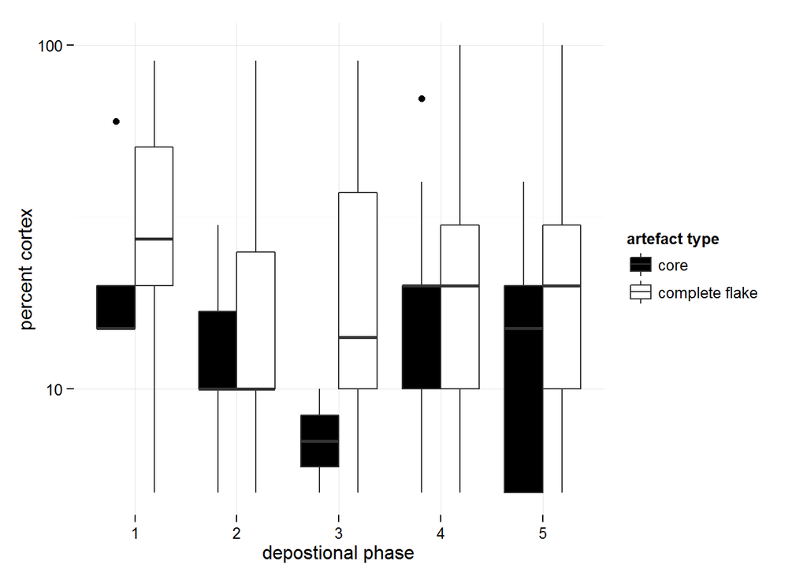

```r
# plot flake and core cortex by phase in one box plot
flakes_cores_cortex <- allchert[(allchert$Artclas == "flake" | allchert$Artclas == "core"), c('Artclas', 'Cortex', 'phase') ]

ggplot(flakes_cores_cortex, aes( fill = Artclas, as.factor(phase), Cortex)) +
  geom_boxplot() +
  scale_y_log10() +
  theme_minimal() +
  xlab('depostional phase') +
  ylab("percent cortex") +
  scale_fill_manual(name="artefact type",
                    labels=c("core", "complete flake"),
                    values = c("black", "white"))
```

```r
# save plot
ggsave("figures/Jeremalai-flake-core-cortex-phase.png")
```

This code computes the test for credible differences in the amount of cortex on flakes and cores by phase.

```r
### Flakes first
# do bayesian ANOVA
data <- data.frame(phase = flakes$phase, cortex = flakes$Cortex)
data <- data[data$cortex != 0,] # zeros break the model)
# This script is in the same folder as the current script
# and generates plots and a lot of data objects. The only
# input is a long data.frame called 'data' that has col1
# as numbers indicating groups and col2 as the measurement
# source("code/BensANOVAonewayJagsSTZ.R")

# Frequentist test also output from that script.
# no credible interactions under expectation of not independant

### Cores second
# do bayesian ANOVA
data <- data.frame(phase = cores_mass$phase, cortex = cores_mass$Cortex)
data <- na.omit(data[data$cortex != 0 ,]) # zeros break the model)
# This script is in the same folder as the current script
# and generates plots and a lot of data objects. The only
# input is a long data.frame called 'data' that has col1
# as numbers indicating groups and col2 as the measurement
# source("code/BensANOVAonewayJagsSTZ.R")

# Frequentist test also output from that script.
# no credible interactions under expectation of not independant
```

### Core technology

This code draws the plot “Cores recovered from Jerimalai. Differences in core mass by type.”

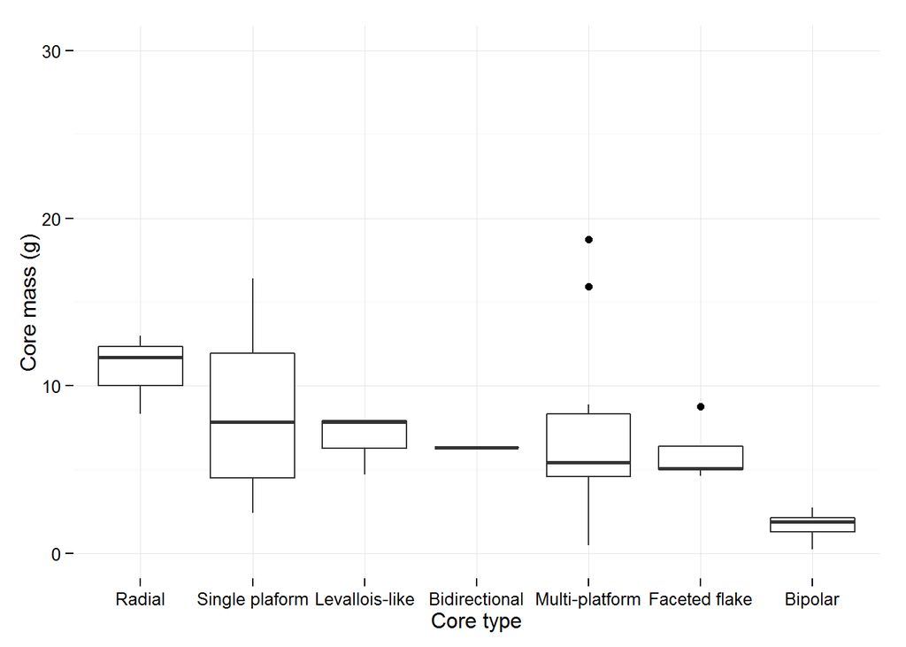

```r
core_types$Type_long <- with(core_types, ifelse(Type == "SPC", "Single plaform",
                                     ifelse(Type == "RC", "Radial",
                                      ifelse(Type == "BDC", "Bidirectional",
                                       ifelse(Type == "BiC", "Bipolar",
                                        ifelse(Type == "MPC", "Multi-platform",
                                         ifelse(Type == "LLC", "Levallois-like",
                                          ifelse(Type == "FFC", "Faceted flake", NA))))))) )

# plot
ggplot(core_types, aes(reorder(Type_long, -Mass,  FUN=median), Mass)) +
  geom_boxplot() +
  ylim(0,30) +
  theme_minimal() +
  xlab("Core type") +
  ylab("Core mass (g)")
```

```r
# save
ggsave("figures/Jeremalai-core-by-type.png")
```

This code computes the linear model coefficients for the the relationship between core maximum dimension and core mass.

```r
# compute linear model
m <-lm(Mass ~ Length, core_types)
# extract coefs into data frame
out <- round(data.frame(a = coef(m)[1],
                       b = coef(m)[2],
                      r2 = summary(m)$r.squared,
                       p =  anova(m)$'Pr(>F)'[1],
                       n = nrow(core_types) ), 3)
```

The maximum dimension of cores is strongly correlated with mass (r2 = 0.618).

This code computes the amount of cortex for each core type.

```r
core_cortex <- aggregate( X..Cortex ~ Type, data = core_types, mean)
# what is the average amount of cortex for each core type?
core_cortex_means <- arrange(core_cortex, -X..Cortex)
names(core_cortex_means) <- c("Type", "Cortex percentage")
core_cortex_means[,2] <- round(core_cortex_means[,2],1)
core_cortex_means
```

```
##   Type Cortex percentage
## 1  BDC              20.0
## 2  SPC              20.0
## 3   RC              10.0
## 4  MPC               6.0
## 5  FFC               4.0
## 6  LLC               3.3
## 7  BiC               2.0
```

This code computes the numbers of flake scars by each core type.

```r
core_scars <- core_types %>%
  group_by(Type) %>%
  summarize(means = round(mean(Number.of.Scars, na.rm = TRUE),0),
            sds = round(sd(Number.of.Scars,  na.rm = TRUE)),0) %>%
  arrange(means)
```

Levallois-like cores exhibit almost twice the number of flake scars on average as other cores in the assemblage (mean = 27±9 scars versus 15±5 on average). Single platform cores have the least scars on average (10±3).

### Retouched artefacts

This code draws the plot “Locations of retouch on chert flakes by depositional unit at Jerimalai square B”

```r
# frequency of flakes with retouch per phase
rt <- flakes[flakes$Rtch == "Yes", ]
rt_tab <- t(data.frame(rt = aggregate(Retype ~ phase, rt, function(x) rt_count = length(x)), flakes =  aggregate(Retype ~ phase, flakes, function(x) fk_count = length(x))[,2] ))

# retouch locations
rt_loc <- data.frame(phase = rt$phase, rt_loc = rt$Retloc)
rt_loc <- rt_loc[!(is.na(rt_loc$phase)), ]
rt_sum <- as.data.frame.matrix(table(rt_loc))[,-1]
rt_sum$phase <- paste0("phase ", row.names(rt_sum))
colnames(rt_sum) <- c("Both margins", "Distal", "Perimeter", "Left lateral", "Medial", "Proximal", "Right lateral", "phase")
rt_sum_m <- melt(rt_sum)
```

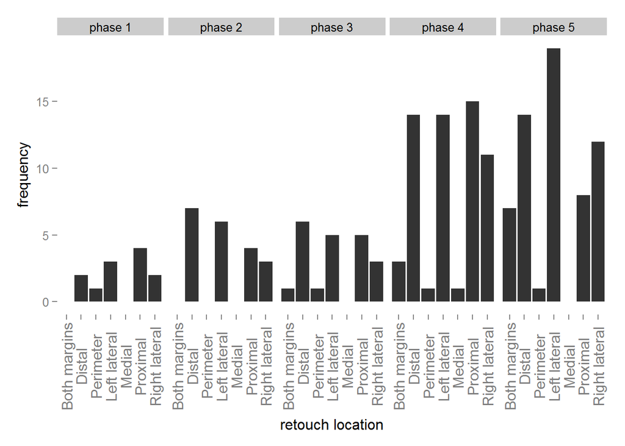

```r
# plot
ggplot(rt_sum_m, aes(variable, value)) +
  geom_bar(stat="identity") +
  theme(axis.text.x  = element_text(angle=90, vjust=0.5, size=12)) +
  ylab("frequency") +
  xlab("retouch location") +
  facet_wrap(~phase, ncol = 5)
```

```r
# save plot
ggsave("figures/Jeremalai-flake-retouched-flake-location-phase.png")
```

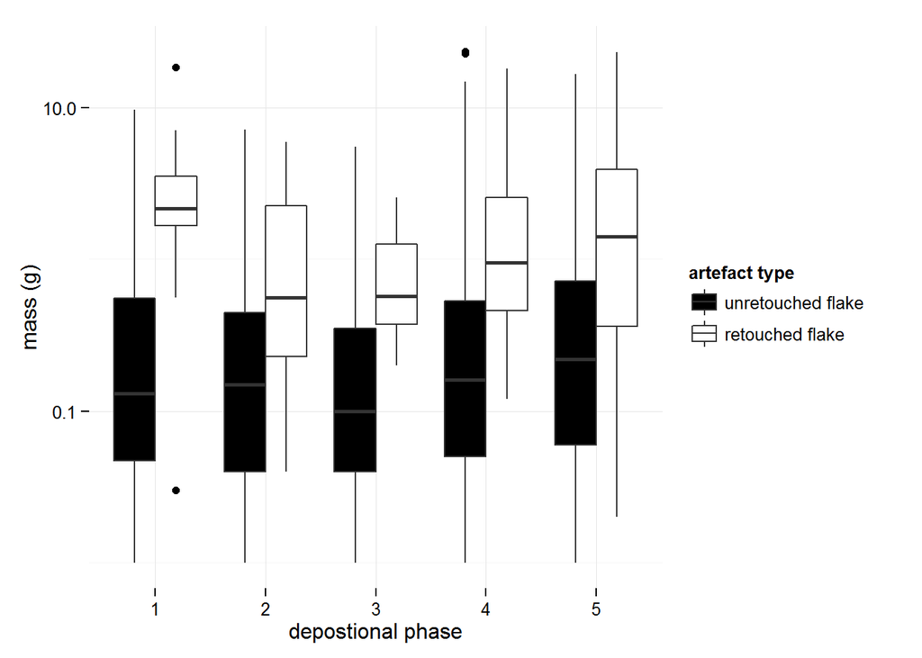

```r
# plot retouch flake size and complete unretouch flake size
#  in one box plot
flakes_retouch_size <- allchert[(allchert$Artclas == "flake" | allchert$Artclas == "retf"), c('Artclas', 'Weight', 'Length', 'phase') ]

ggplot(flakes_retouch_size, aes( fill = Artclas, as.factor(phase), Weight)) +
  geom_boxplot() +
  scale_y_log10() +
  theme_minimal() +
  xlab('depostional phase') +
  ylab("mass (g)") +
  scale_fill_manual(name="artefact type",
                    labels=c("unretouched flake", "retouched flake"),
                    values = c("black", "white"))
```

```r
# save plot
ggsave("figures/Jeremalai-flake-retouchedflake-mass-phase.png")
```

This code computes the tests for credible difference in retouch flake lengths by phase

```r
# send out for bayesian contingency table test...
# reshape and give meaningful names...
colnames(rt_tab) <- c("phase 1", "phase 2", "phase 3", "phase 4", "phase 5" )
rt_tab <- rt_tab[-1,]
data <- melt(as.matrix(rt_tab),  varnames=c("retouch", "phase"), value.name="Freq")
data <- data[data$Freq != 0 | !is.numeric(data$Freq),] # zeros break the model
# This script is in the same folder as the current script
# and generates plots and a lot of data objects. The only
# input is a long data.frame called 'data' that has a last
# column called 'Freq'
# source("code/BensPoissonExponentialJagsSTZ.R")

# nothing from bayes, nothing from freq.
freq_test <- assocstats(as.matrix(rt_tab))

# get proportion
rt_tab <- data.frame(t(rt_tab))
rt_tab$prop <- with(rt_tab, (rt.Retype/flakes))

# amount of the flake that is retouched as measured by retouch length

rt_len <- data.frame(phase = rt$phase, rt_len = rt$Retlen)
# omit NAs
rt_len <- rt_len[!(is.na(rt_len$rt_len)), ]

# get mean lengths
mean_lengths <- aggregate(rt_len ~ phase, rt_len, mean)

# do bayesian ANOVA
data <- rt_len
data <- na.omit(data[data$rt_len != 0 ,]) # zeros break the model)
# This script is in the same folder as the current script
# and generates plots and a lot of data objects. The only
# input is a long data.frame called 'data' that has col1
# as numbers indicating groups and col2 as the measurement
# source("code/BensANOVAonewayJagsSTZ.R")

# no credible differences



# any difference between mass of retouched and unretouched, in total?
# Bayesian t-test of the mass of all retouched vs all unretouched flakes
# flakes_retouch_size_t_test <- BESTmcmc(flakes_retouch_size[flakes_retouch_size$Artclas == "flake", ]$Weight, flakes_retouch_size[flakes_retouch_size$Artclas == "retf", ]$Weight)
```

This code makes the table “Summary of retouch indices for retouched pieces recovered from Jerimalai. GIUR = Geometric Index of Unifacial Retouch, II = Index of Invasiveness, % = percent of perimeter with retouch”

```r
retouch_indices[is.na(retouch_indices)] <- 0
retouch_indices$GIUR <- with(retouch_indices, t1/T1 + t2/T2 + t3/T3)/3
retouch_indices$perimeter_perc <- with(retouch_indices, length/perimeter * 100)
retouch_indices$II <- with(retouch_indices, ((X0.5 * 0.5) + (X1 * 1))/16)
# get mean and standard deviation for each index
retouch_indices_subset <- retouch_indices %>% select(GIUR, perimeter_perc, II)
# sweep over the columns to compute mean and standard deviation
retouch_indices_means <- data.frame(t(round(apply(retouch_indices_subset, 2, mean, na.rm = TRUE),2)))
retouch_indices_sds <- data.frame(t(round(apply(retouch_indices_subset, 2, sd, na.rm = TRUE),2)))
# make table
retouch_table <- retouch_indices %>%
  select(Square, Spit, Type, GIUR, II, perimeter_perc)
# do some rounding
retouch_table[,4:6] <- apply(retouch_table[,4:6], 2, round, 2)
# have a look
retouch_table <- arrange(retouch_table, Spit)
# write the table to a csv file so we can put it in the word doc
write.csv(retouch_table, file = 'retouch_table.csv', row.names = FALSE)
```

The retouch intensity can be summarised with the following metrics: GIUR = 0.51 +/- 0.21 perimeter = 29.48 +/- 14.09% II = 0.16 +/- 0.13

### Technological types

This code makes the table “Summary of counts and classes. Counts refers to the count of spits in each depositional phase containing a given class.”

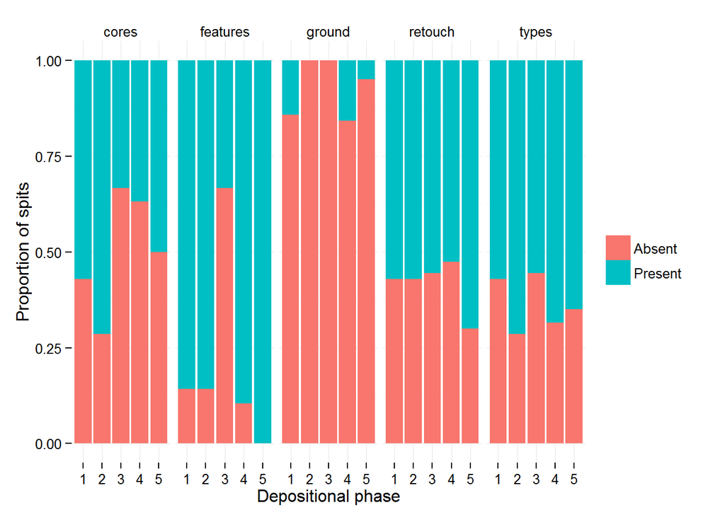

```r
# all

# combine

techno <- data.frame(cores, types, retouch, features, ground,  stringsAsFactors = FALSE)
# remove extra Spit cols (is those called 'Spit.1' etc)
techno <- techno[,-grep("Spit\\.", colnames(techno)) ]
# put depths on
techno$depth <- depths$Depth.bs..m[match(techno$Spit,depths$Spit.no)]
# put phases on
techno$phase <- flakes$phase[match(techno$Spit,flakes$Spit)]

# Chi Square based on % of spits in each temporal block that have a technological type present

techno[] <- lapply(techno, as.character) # change factor to character
techno[techno == 'x'] <-  1 # replace x with 1
techno[] <- lapply(techno, as.numeric) # change char to num
# get row sums
rs <- rowSums(techno[,2:32], na.rm = TRUE )
# get row sums by group
rs_phase <- data.frame(rs, phase = techno$phase)
# % that have a type present
# phases with no types at all
check <- rs_phase[rs_phase$rs == 0,]
# set 1 or above to 1
rs_phase$rs <- ifelse(rs_phase$rs == 0, 0, 1)
check <- aggregate(rs ~ phase, rs_phase[rs_phase$rs == 0,], length) # counts
check <- t(apply(table(rs_phase), 2, function(x) x/sum(x))) # props
# just three spits with zero types... let's do it by class

## cores ##
# put depths on
cores$depth <- depths$Depth.bs..m[match(cores$Spit,depths$Spit.no)]
# put groups on
cores$phase <- flakes$phase[match(cores$Spit,flakes$Spit)]
cores[] <- lapply(cores, as.character) # change factor to character
cores[cores == 'x'] <-  1 # replace x with 1
cores[] <- lapply(cores, as.numeric) # change char to num
# get row sums
rs <- rowSums(cores[,2:(ncol(cores)-2)], na.rm = TRUE )
# get row sums by phase
rs_phase <- data.frame(rs, group = cores$phase)
# % that have a type present
# groups with no types at all
check <- rs_phase[rs_phase$rs == 0,]
# set any non-zero to 1
rs_phase$rs <- ifelse(rs_phase$rs != 0, 1, rs_phase$rs)
# yes, more with zero here...
dc_core <- data.frame(t(apply(table(rs_phase), 2, function(x) x/sum(x))))
dc_core <- prop.table(as.matrix(dc_core), 1)
# chi-square test
csq <- chisq.test(dc_core, simulate.p.value=T, B=9999)


## types ##
# put depths on
types$depth <- depths$Depth.bs..m[match(types$Spit,depths$Spit.no)]
# put groups on
types$phase <- flakes$phase[match(types$Spit,flakes$Spit)]
types[] <- lapply(types, as.character) # change factor to character
types[types == 'x'] <-  1 # replace x with 1
types[] <- lapply(types, as.numeric) # change char to num
# get row sums
rs <- rowSums(types[,2:(ncol(types)-2)], na.rm = TRUE )
# get row sums by group
rs_phase <- data.frame(rs, phase = types$phase)
# % that have a type present
# groups with no types at all
check <- rs_phase[rs_phase$rs == 0,]
# set any non-zero to 1
rs_phase$rs <- ifelse(rs_phase$rs != 0, 1, rs_phase$rs)
# yes, more with zero here...
dc_types <- data.frame(t(apply(table(rs_phase), 2, function(x) x/sum(x))))
dc_types <- prop.table(as.matrix(dc_types), 1)
# chi-square test
csq <- chisq.test(dc_types, simulate.p.value=T, B=9999)


## retouch ##
# put depths on
retouch$depth <- depths$Depth.bs..m[match(retouch$Spit,depths$Spit.no)]
# put groups on
retouch$phase <- flakes$phase[match(retouch$Spit,flakes$Spit)]
retouch[] <- lapply(retouch, as.character) # change factor to character
retouch[retouch == 'x'] <-  1 # replace x with 1
retouch[] <- lapply(retouch, as.numeric) # change char to num
# get row sums
rs <- rowSums(retouch[,2:(ncol(retouch)-2)], na.rm = TRUE )
# get row sums by group
rs_phase <- data.frame(rs, phase = retouch$phase)
# % that have a type present
# groups with no types at all
check <- rs_phase[rs_phase$rs == 0,]
# set any non-zero to 1
rs_phase$rs <- ifelse(rs_phase$rs != 0, 1, rs_phase$rs)
# yes, more with zero here...
dc_retouch <- data.frame(t(apply(table(rs_phase), 2, function(x) x/sum(x))))
dc_retouch <- prop.table(as.matrix(dc_retouch), 1)
# chi-square test
csq <- chisq.test(dc_retouch, simulate.p.value=T, B=9999)


## features ##
# put depths on
features$depth <- depths$Depth.bs..m[match(features$Spit,depths$Spit.no)]
# put groups on
features$phase <- flakes$phase[match(features$Spit,flakes$Spit)]
features[] <- lapply(features, as.character) # change factor to character
features[features == 'x'] <-  1 # replace x with 1
features[] <- lapply(features, as.numeric) # change char to num
# get row sums
rs <- rowSums(features[,2:(ncol(features)-2)], na.rm = TRUE )
# get row sums by group
rs_phase <- data.frame(rs, phase = features$phase)
# % that have a type present
# groups with no types at all
check <- rs_phase[rs_phase$rs == 0,]
# set any non-zero to 1
rs_phase$rs <- ifelse(rs_phase$rs != 0, 1, rs_phase$rs)
# yes, more with zero here...
dc_feat <- data.frame(t(apply(table(rs_phase), 2, function(x) x/sum(x))))
dc_feat <- prop.table(as.matrix(dc_feat), 1)
# chi-square test
csq <- chisq.test(dc_feat, simulate.p.value=T, B=9999)

## ground ##
# put depths on
ground$depth <- depths$Depth.bs..m[match(ground$Spit,depths$Spit.no)]
# put phases on
ground$phase <- flakes$phase[match(ground$Spit,flakes$Spit)]
ground[] <- lapply(ground, as.character) # change factor to character
ground[ground == 'x'] <-  1 # replace x with 1
ground[] <- lapply(ground, as.numeric) # change char to num
# get row sums
rs <- rowSums(ground[,2:(ncol(ground)-2)], na.rm = TRUE )
# get row sums by phase
rs_phase <- data.frame(rs, phase = ground$phase)
# % that have a type present
# phases with no types at all
check <- rs_phase[rs_phase$rs == 0,]
# set any non-zero to 1
rs_phase$rs <- ifelse(rs_phase$rs != 0, 1, rs_phase$rs)
# yes, more with zero here...
dc_gr <- data.frame(t(apply(table(rs_phase), 2, function(x) x/sum(x))))
dc_gr <- prop.table(as.matrix(dc_gr), 1)
# chi-square test
csq <- chisq.test(dc_gr, simulate.p.value=T, B=9999)

# put them together
lst <- list(cores = dc_core,  retouch = dc_retouch, types = dc_types, features = dc_feat,  ground = dc_gr)
df <- ldply(lst, data.frame)
df$phase <- rep(seq_along(unique(na.omit(flakes$phase))), length(lst))

# plot proportion of spits having a techno-type present
df_m <- melt(df, id.var = c('phase', '.id'))
df_m$variable <- ifelse(df_m$variable == 'X0', 'Absent', 'Present')
ggplot(df_m, aes(as.factor(phase), value, fill = variable)) +
  geom_bar(stat="identity") +
  facet_grid(. ~ .id) +
  theme_minimal() +
  xlab("Depositional phase") +
  ylab("Proportion of spits") +
  scale_fill_discrete(name="")
```

```r
ggsave("figures/Jeremalai-techno-types.png")
# now we can see, let's explore some of the minor patterns...
# what are the counts of each class in each phase?

# more about features
l <- lapply(features[,2:(ncol(features)-2)], function(i)  aggregate( i ~ phase, features, sum, na.rm = TRUE))
df <- do.call(rbind.data.frame, l)
df$name <- unlist(lapply(1:length(l), function(i) rep(names(l)[i], nrow(l[[i]]))))
feat <- dcast(phase ~ name, value.var = 'i', data = df)

# more about ground
l <- lapply(ground[,2:(ncol(ground)-2)], function(i)  aggregate( i ~ phase, ground, sum, na.rm = TRUE))
df <- do.call(rbind.data.frame, l)
df$name <- unlist(lapply(1:length(l), function(i) rep(names(l)[i], nrow(l[[i]]))))
grou <- dcast(phase ~ name, value.var = 'i', data = df)

# more about retouch
l <- lapply(retouch[,2:(ncol(retouch)-2)], function(i)  aggregate( i ~ phase, retouch, sum, na.rm = TRUE))
df <- do.call(rbind.data.frame, l)
df$name <- unlist(lapply(1:length(l), function(i) rep(names(l)[i], nrow(l[[i]]))))
reto <- dcast(phase ~ name, value.var = 'i', data = df)

# more about types
l <- lapply(types[,2:(ncol(types)-2)], function(i)  aggregate( i ~ phase, types, sum, na.rm = TRUE))
df <- do.call(rbind.data.frame, l)
df$name <- unlist(lapply(1:length(l), function(i) rep(names(l)[i], nrow(l[[i]]))))
type <- dcast(phase ~ name, value.var = 'i', data = df)

# more about cores
l <- lapply(cores[,2:(ncol(cores)-2)], function(i)  aggregate( i ~ phase, cores, sum, na.rm = TRUE))
df <- do.call(rbind.data.frame, l)
df$name <- unlist(lapply(1:length(l), function(i) rep(names(l)[i], nrow(l[[i]]))))
core <- dcast(phase ~ name, value.var = 'i', data = df)

# obsidian?
all$phase <- makephases(all$Spit)
obsidian <- table(data.frame(phase = all$phase, rm = all$Material))

# summary table of all techno-types. This will give a count of spits
# in each phase that contain at least one artefact in the category.
summaryt <- (t(cbind(
  ddply(retouch[,2:(ncol(retouch))], "phase", numcolwise(sum, na.rm = TRUE)),
  ddply(features[,2:(ncol(features))], "phase", numcolwise(sum, na.rm = TRUE)),
  ddply(ground[,2:(ncol(ground))], "phase", numcolwise(sum, na.rm = TRUE)),
  ddply(types[,2:(ncol(types))], "phase", numcolwise(sum, na.rm = TRUE)),
  ddply(cores[,2:(ncol(cores))], "phase", numcolwise(sum, na.rm = TRUE))
)))
summaryt <- summaryt[!(row.names(summaryt) %in% c("depth", "phase")),]
# compute proportions so we have the proportion of spits in each phase
# that contains at least one of each class.
spits_per_phase <- aggregate(Spit ~ phase, data = cores, length)
summaryt_props <- round(t(t(summaryt) / spits_per_phase$Spit),2)

# write table to csv to put into word doc
write.csv(summaryt_props, "techno_types_table.csv")
# this is table 6
summaryt_props
```

```
##                                                 [,1] [,2] [,3] [,4] [,5]
## Distal                                          0.43 0.29 0.11 0.11 0.50
## Lateral                                         0.14 0.14 0.22 0.21 0.40
## Notched                                         0.00 0.00 0.00 0.16 0.30
## Lateral.and.Distal                              0.14 0.14 0.11 0.00 0.05
## Double.Side.and.End                             0.14 0.14 0.11 0.05 0.20
## Denticulated                                    0.00 0.00 0.00 0.05 0.05
## Notched.Lateral.and.Distal                      0.00 0.00 0.11 0.00 0.00
## Drill.Like.Retouch...Edge.Damage                0.00 0.00 0.00 0.00 0.10
## Old.Ventral.Suface.on.Dorsal...Faceted.Platform 0.57 0.71 0.11 0.53 0.40
## Platform.Faceting                               0.86 0.86 0.33 0.84 0.95
## Flake.With.Old.Ventral.on.Dorsal                0.00 0.00 0.00 0.11 0.40
## Truncated.Flake                                 0.00 0.00 0.00 0.05 0.00
## Flakes.With.Gloss                               0.00 0.00 0.00 0.05 0.15
## Ground.Ochre                                    0.00 0.00 0.00 0.05 0.00
## Possible.Ground.Flake..Axe.Flake..              0.14 0.00 0.00 0.00 0.00
## Striated.haematite                              0.00 0.00 0.00 0.11 0.05
## Microblade                                      0.14 0.43 0.11 0.37 0.10
## Levallois.Like.Flake                            0.00 0.29 0.00 0.11 0.00
## Burin.Spall                                     0.29 0.00 0.11 0.00 0.20
## Faceted.Point                                   0.14 0.29 0.00 0.00 0.00
## Bipolar.Flake                                   0.00 0.00 0.11 0.11 0.20
## Éclat.Debordant                                 0.00 0.00 0.11 0.21 0.00
## Cortical.Flake                                  0.14 0.14 0.00 0.05 0.15
## Redirecting.Flake                               0.00 0.14 0.11 0.26 0.45
## Chopper.Anvil                                   0.00 0.00 0.11 0.00 0.05
## Semi.Discoidal                                  0.00 0.14 0.11 0.00 0.10
## Faceted.Radial...Levallois                      0.14 0.43 0.00 0.05 0.15
## Truncated.Faceted.Flake                         0.14 0.43 0.00 0.05 0.05
## Bipolar                                         0.14 0.14 0.00 0.05 0.20
## Bidirectional                                   0.00 0.14 0.11 0.05 0.10
## Single.Platform                                 0.14 0.14 0.00 0.05 0.20
## Mulitplatform                                   0.29 0.29 0.11 0.16 0.20
```